[News](http://diarsproject.github.io/DIARS/News.html)

[About](http://diarsproject.github.io/DIARS/About.html)

# Welcome to the DIARS toolbox

[Invasive species](http://ec.europa.eu/environment/nature/invasivealien/index_en.htm) are defined as alien species that have been transported outside their natural ecological range by humans. With the rapid increase in world trade and transportation, these species have become a major threat to biodiversity, human health and economical development, thus the urgent need to accurately control and manage these invasions. Unfortunately, this task has been limited by our ability to detect, monitor and assess the impact of invasive species from the ground. In this context, the recent advances in remote sensing combined with the increasing availability of free and open-source software provide a powerful opportunity to tackle this challenge and generate relevant knowledge and tools to monitor species invasions combining field and remote sensing observations.

This website is part of the [**DIARS project**](http://diars.vgt.vito.be/content/home) that brings together European experts from remote sensing and ecology to demonstrate and characterize the impact of invasive species on ecosystems through the combined use of field data and data obtained through remote-sensing technologies and support the monitoring and prediction of spread and risk assessment of invasive plant species. It consists of a toolbox with tutorials that walk you through a **remote sensing-based framework for mapping, modelling and assessing the impact of biological invasions**.

### How to use it?

##### Install R and GRASS GIS software

Before starting to work with this tutorial, make sure you have a recent version of [R](https://cran.r-project.org) and [GRASS GIS](https://grass.osgeo.org/grass7/) installed and ready to use on your computer. You can find a GRASS GIS quick start guide [HERE](https://grass.osgeo.org/grass70/manuals/helptext.html).

##### Explore the toolbox!

The tutorials start with a general background highlighting the aim of the tutorial, specifying the software required and, providing a link to download the dataset, followed by a step-by-step guide that includes a series of “best practices” tips (gray boxes) that will help you improve the quality of your analyses when applying this framework to your case study.

Keep in mind that the outcomes obtained from the data preparation section might be required to work with some of the applications.

#### Data preparation

Hyperspectral and LiDAR data contain complex information on the biochemistry and 3D structure of the forest. This type of high-resolution remote sensing data can help improve the field sampling design and the species distribution modelling process. Therefore, to accurately derive meaningful variables for biological invasions it is necessary to perform some data pre-processing.

In this section you will find: LiDAR preprocessing, Hyperspectral preprocessing, and two methods to generate a field samples that include the environmental heterogeneity and select contingent absences. Click on the panels below to access the tutorials.

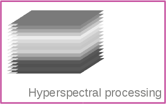

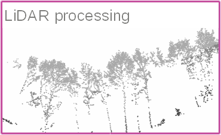

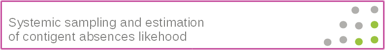

#### Applications

The variables derived from the remote sensing data are used to detect and map invasive species distribution, to predict the spread of the invasive species and identify vulnerable areas via species distribution models, and to assess their impact on the ecosystem. Click on the circles below to access the tutorial for each of these applications.

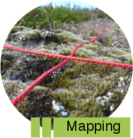

[figure not shown]

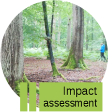

###### Back to the top

**Authors**: Carol Garzon-Lopez, Tarek Hattab, Duccio Rocchini & Jonathan Lenoir

**Date**: 2016-12-05

*Built with RMarkdown and hosted on Github Pages.*